# PCA Image Compression

```r
compress_image <- function(X, k) {
  V <- t(X) %*% X
  eigen <- eigen(V)

  U <- eigen$vectors

  Z <- X %*% U

  Z_k <- Z[, 1:k]
  U_k <- U[, 1:k]
  X_k <- Z_k %*% t(U_k)

  # calculate error
  error <- norm(X - X_k, type = 'F')

  return(list(k_approx = X_k, F_error = error))
}
```

```r
plot_image <- function(image_matrix, title) {
  index <- nrow(image_matrix):1

  image(
    t(image_matrix[index, ]),
    col = gray.colors(256),
    axes = FALSE,
    main = title,
    cex.main = 3
  )
}
```

## Image 1

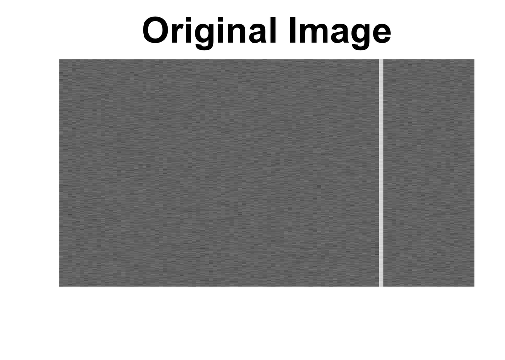

```r
# make 1x1 frame and plot og image
par(mfrow = c(1, 1))
plot_image(x1, "Original Image")
```

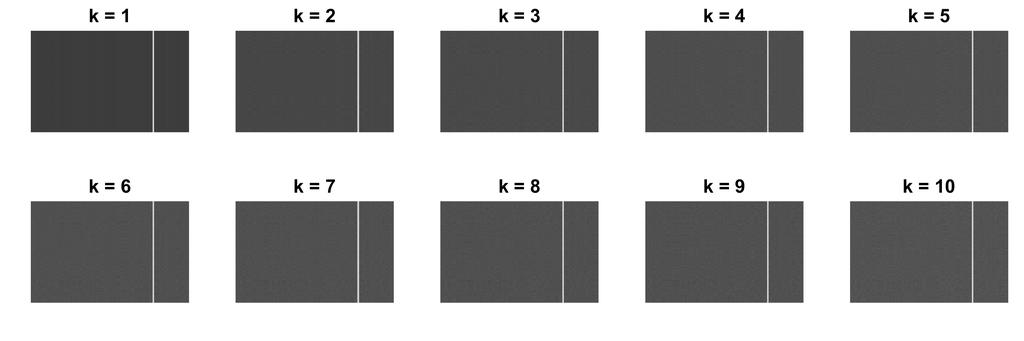

```r
# make 2x5 frame and plot compressed images k = 1-10
par(mfrow = c(2, 5))
for (k in 1:10) {
  result <- compress_image(x1, k)

  plot_image(
    result$k_approx,
    paste("k =", k)
  )
}
```

### Approximation Error vs. k

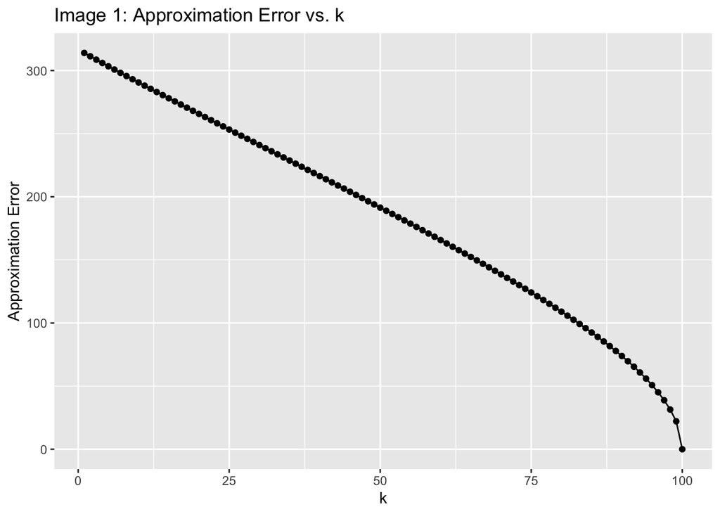

```r
k_values <- 1:ncol(x1)
error_vector <- numeric(length(k_values))

for (k in k_values) {
  result <- compress_image(x1, k)
  error_vector[k] <- result$F_error
}

error_data <- data.frame(
  k = k_values,
  error = error_vector)

ggplot(error_data, aes(x = k, y = error)) + geom_line() + geom_point() +
  labs(x = "k", y = "Approximation Error", title = "Image 1: Approximation Error vs. k")
```

### First Eigenvector and First Principal Component

```r
V <- t(x1) %*% x1
  eigen <- eigen(V)
U <- eigen$vectors
Z <- x1 %*% U
first_eigenvector <- U[, 1]
first_PCscore <- Z[, 1]

eigenvector_data <- data.frame(
  index = 1:length(first_eigenvector),
  value = first_eigenvector
)

PCscore_data <- data.frame(
  index = 1:length(first_PCscore),
  value = first_PCscore
)
```

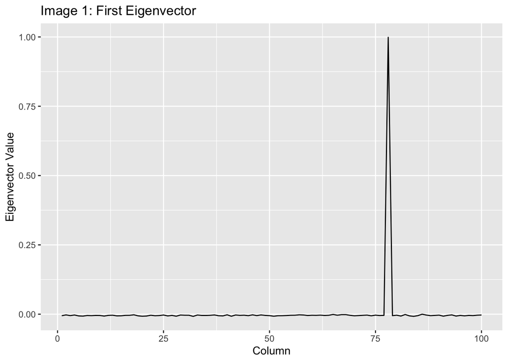

```r
ggplot(eigenvector_data, aes(x = index, y = value)) +
  geom_line() +
  labs(
    x = "Column",
    y = "Eigenvector Value",
    title = "Image 1: First Eigenvector"
  )
```

**Interpretation:** The first eigenvector describes the main pattern captured by the first principal component across the columns of the image. Its values are close to zero for almost every column except around column 78, where the weight is close to 1. This large magnitude around column 78 corresponds to the distinct bright vertical line visible in the original image, indicating that this line is the main pattern captured by the first principal component.

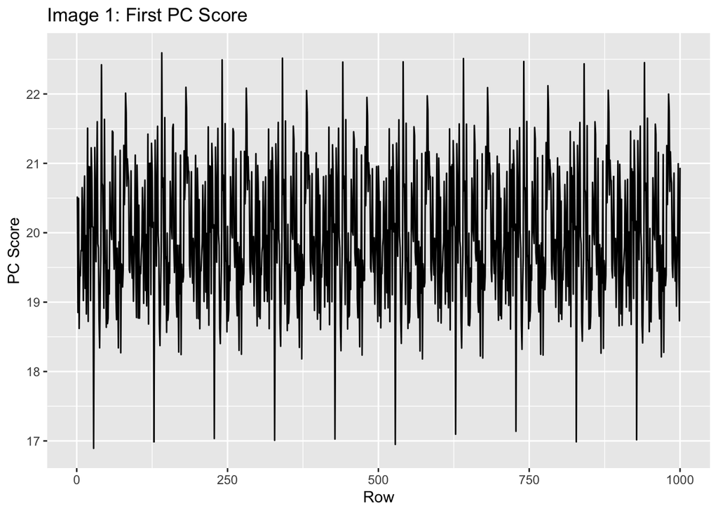

```r
ggplot(PCscore_data, aes(x = index, y = value)) +
  geom_line() +
  labs(
    x = "Row",
    y = "PC Score",
    title = "Image 1: First PC Score"
  )
```

**Interpretation:** The first PC scores then describe how strongly this pattern appears in each row of the image. Most of the scores remain around 19 to 21, with relatively small fluctuations across the rows. Since the pattern identified by the first eigenvector is concentrated around column 78, these scores describe how strongly the vertical line appears in each row. The relatively consistent scores indicate that the vertical line is present with similar strength throughout most of the rows, while the fluctuations reflect slight changes in its strength. Together, the first eigenvector identifies the vertical line as the main pattern, while the first PC scores show how much of that pattern appears in each row.

**Sufficient k:** The image is sufficiently good at k = 1 because the main feature of the original image, the bright vertical line around column 78, is already captured by the first principal component. Although the approximation error plot shows a steady decrease as k increases, visually the rank 1 approximation already captures the image well. Therefore, adding more principal components would reduce the numerical error but provide little meaningful visual improvement.

## Image 2

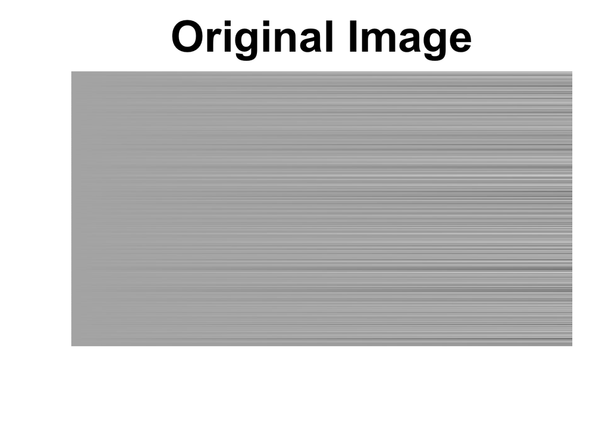

```r
# make 1x1 frame and plot og image
par(mfrow = c(1, 1))
plot_image(x2, "Original Image")
```

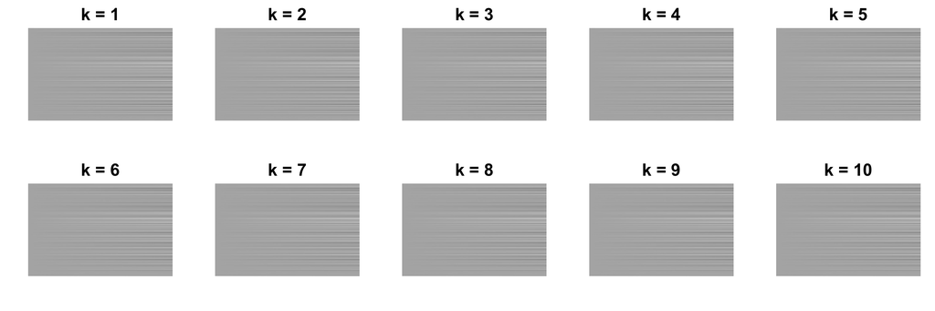

```r
# make 2x5 frame and plot compressed images k = 1-10
par(mfrow = c(2, 5))
for (k in 1:10) {
  result <- compress_image(x2, k)

  plot_image(
    result$k_approx,
    paste("k =", k)
  )
}
```

### Approximation Error vs. k

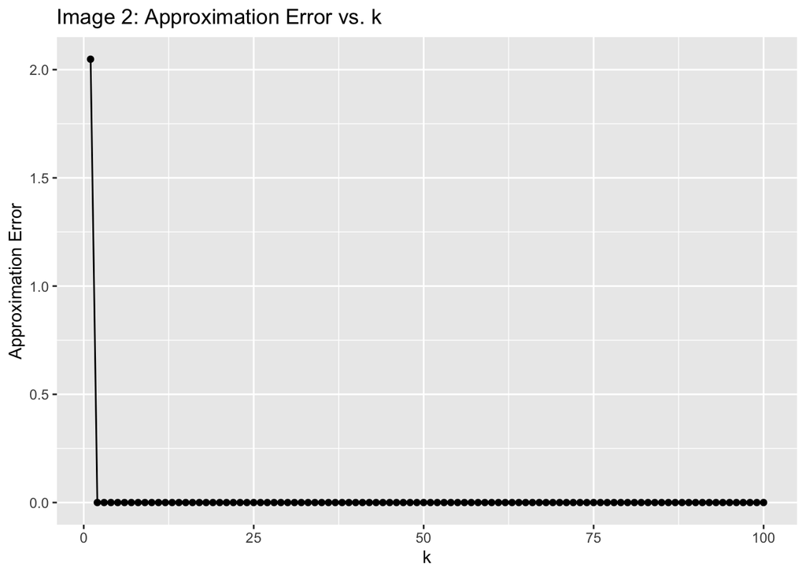

```r
k_values <- 1:ncol(x2)
error_vector <- numeric(length(k_values))

for (k in k_values) {
  result <- compress_image(x2, k)
  error_vector[k] <- result$F_error
}

error_data <- data.frame(
  k = k_values,
  error = error_vector)

ggplot(error_data, aes(x = k, y = error)) + geom_line() + geom_point() +
  labs(x = "k", y = "Approximation Error", title = "Image 2: Approximation Error vs. k")
```

### First Eigenvector and First Principal Component

```r
V <- t(x2) %*% x2
  eigen <- eigen(V)
U <- eigen$vectors
Z <- x2 %*% U
first_eigenvector <- U[, 1]
first_PCscore <- Z[, 1]

eigenvector_data <- data.frame(
  index = 1:length(first_eigenvector),
  value = first_eigenvector
)

PCscore_data <- data.frame(
  index = 1:length(first_PCscore),
  value = first_PCscore
)
```

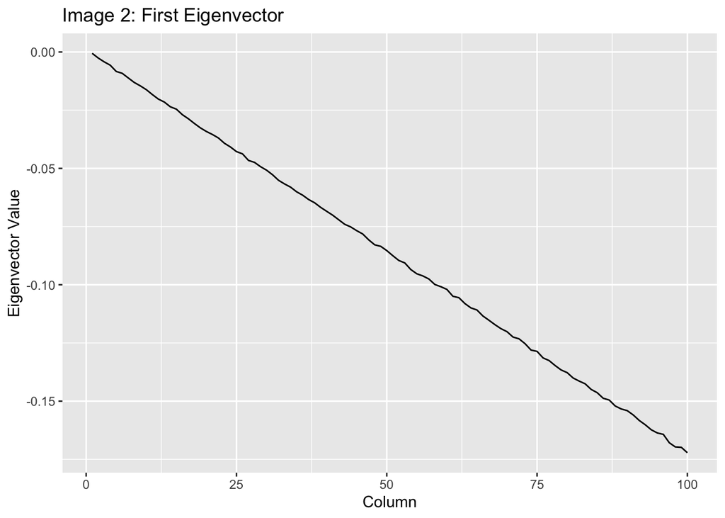

```r
ggplot(eigenvector_data, aes(x = index, y = value)) +
  geom_line() +
  labs(
    x = "Column",
    y = "Eigenvector Value",
    title = "Image 2: First Eigenvector"
  )
```

**Interpretation:** The first eigenvector gradually decreases in value as the column number increases, meaning that the weights become larger in magnitude toward the right side of the image. The dominant pattern represented by the first eigenvector is therefore a gradual change across the columns rather than one specific feature at a single column, unlike Image 1. The original image reflects this, showing a shading gradient from left to right, from lighter to darker. The increasing magnitude of the eigenvector weights across the columns reflects this horizontal change in intensity.

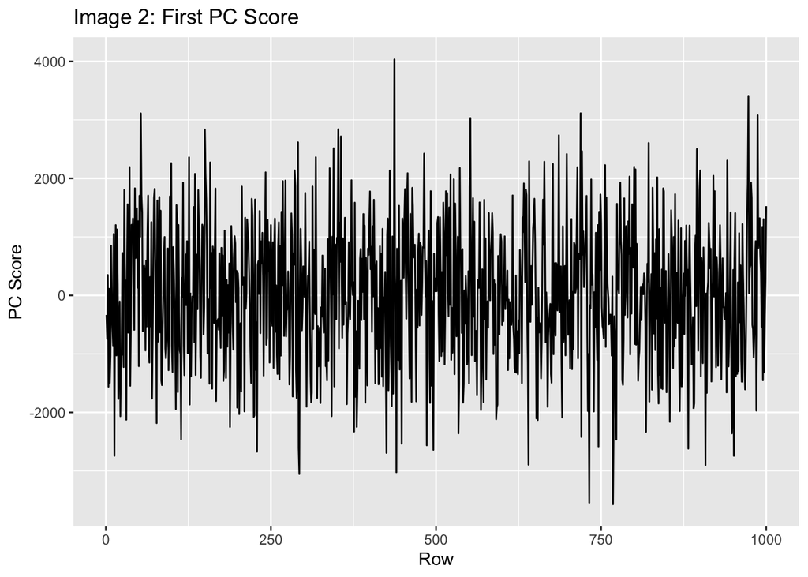

```r
ggplot(PCscore_data, aes(x = index, y = value)) +
  geom_line() +
  labs(
    x = "Row",
    y = "PC Score",
    title = "Image 2: First PC Score"
  )
```

**Interpretation:** The scores remain generally centered around zero without a clear increasing or decreasing trend across the rows, although there are some individual peaks and dips. Thus, the strength of the dominant left-to-right pattern is relatively consistent up and down the image, which matches the original image where the shading gradient appears throughout most of the rows.

**Sufficient k:** The image is sufficiently good at k = 2 because the approximation error decreases sharply from k = 1 to k = 2 and is nearly zero afterward. While the first principal component already captures the main gradient across the columns and the general fluctuations in light and dark across the rows, the second principal component and onwards capture more and more of the remaining finer line-by-line variation. Since increasing k beyond 2 provides almost no further reduction in error, k = 2 provides a sufficiently accurate representation of the original image.

## Image 3

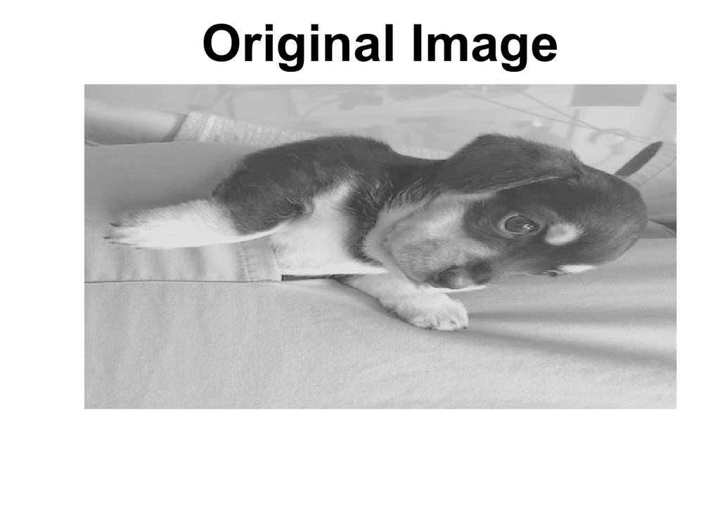

```r
# make 1x1 frame and plot og image
par(mfrow = c(1, 1))
plot_image(x3, "Original Image")
```

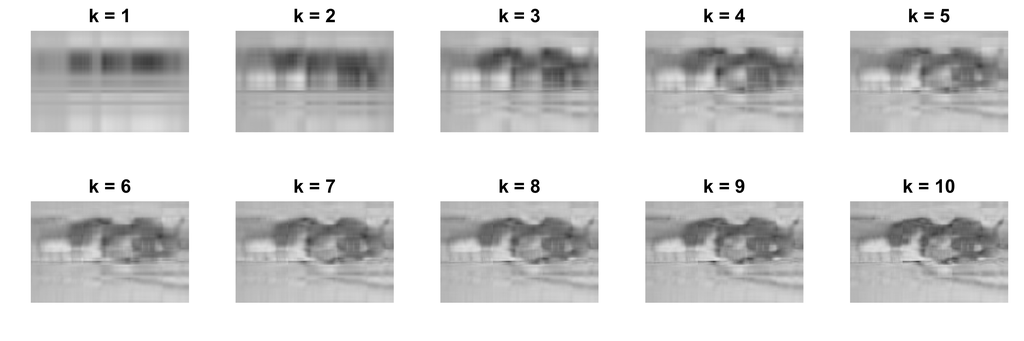

```r
# make 2x5 frame and plot compressed images k = 1-10
par(mfrow = c(2, 5))
for (k in 1:10) {
  result <- compress_image(x3, k)

  plot_image(
    result$k_approx,
    paste("k =", k)
  )
}
```

### Approximation Error vs. k

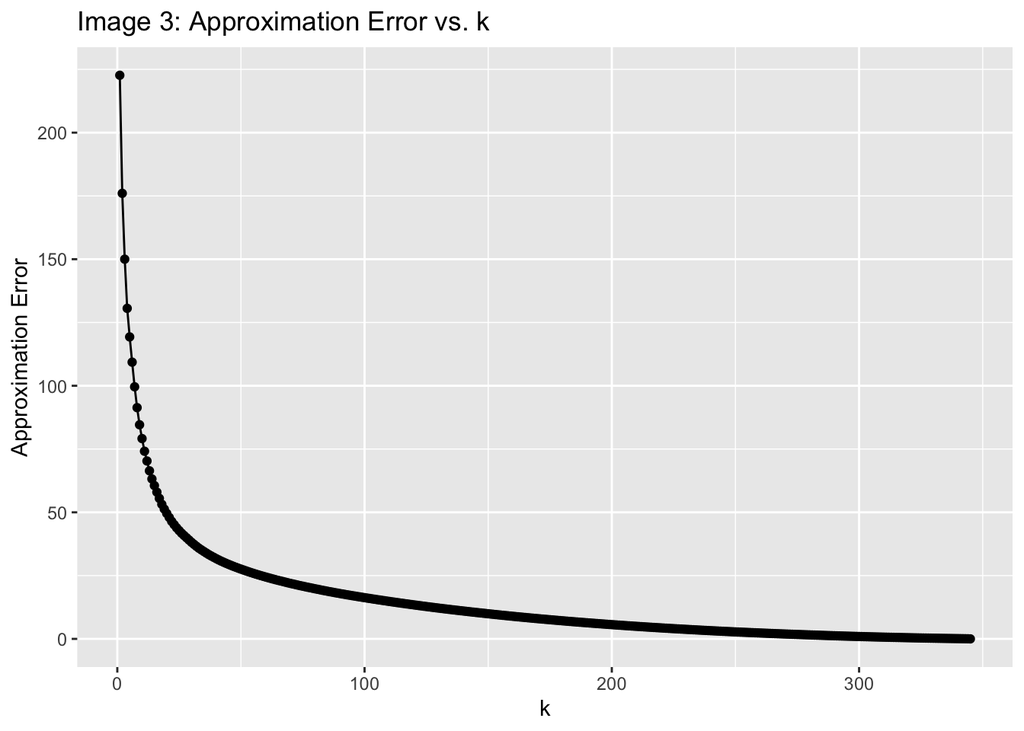

```r
k_values <- 1:ncol(x3)
error_vector <- numeric(length(k_values))

for (k in k_values) {
  result <- compress_image(x3, k)
  error_vector[k] <- result$F_error
}

error_data <- data.frame(
  k = k_values,
  error = error_vector)

ggplot(error_data, aes(x = k, y = error)) + geom_line() + geom_point() +
  labs(x = "k", y = "Approximation Error", title = "Image 3: Approximation Error vs. k")
```

### First Eigenvector and First Principal Component

```r
V <- t(x3) %*% x3
  eigen <- eigen(V)
U <- eigen$vectors
Z <- x3 %*% U
first_eigenvector <- U[, 1]
first_PCscore <- Z[, 1]

eigenvector_data <- data.frame(
  index = 1:length(first_eigenvector),
  value = first_eigenvector
)

PCscore_data <- data.frame(
  index = 1:length(first_PCscore),
  value = first_PCscore
)
```

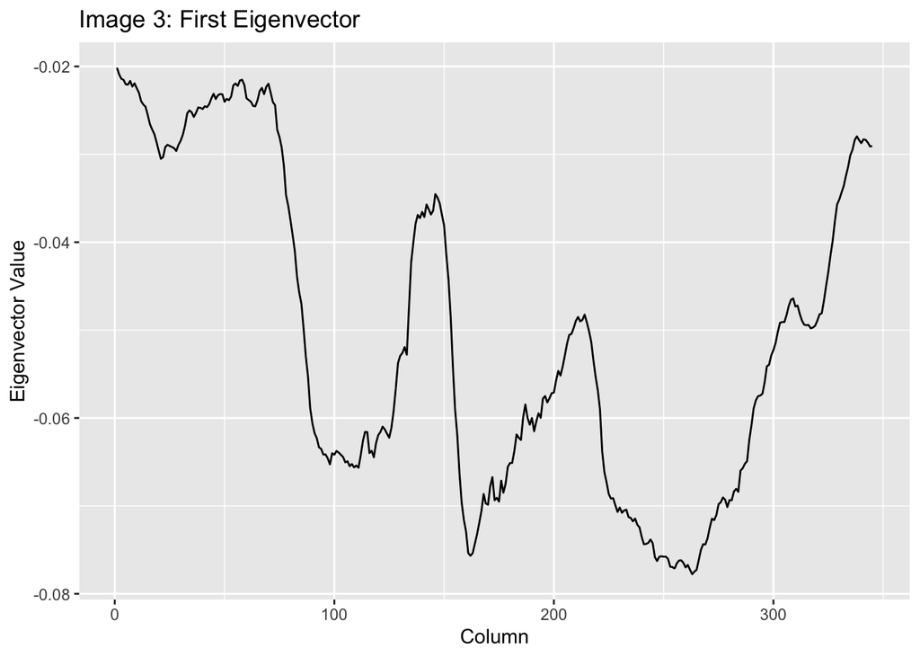

```r
ggplot(eigenvector_data, aes(x = index, y = value)) +
  geom_line() +
  labs(
    x = "Column",
    y = "Eigenvector Value",
    title = "Image 3: First Eigenvector"
  )
```

**Interpretation:** The first eigenvector varies considerably across the columns, unlike the simpler patterns seen in Images 1 and 2. The weights have larger magnitudes in several regions, particularly around columns 90–130, 160–180, and 240–270. These fluctuations indicate that the first principal component captures a pattern involving multiple regions across the image rather than being dominated by a single column or a simple gradient. These changes correspond to major differences in light and dark across the original image. For example, in the k = 1 compression, there are three clear darker regions where the dog is located, which appear to align with the changes in the first eigenvector.

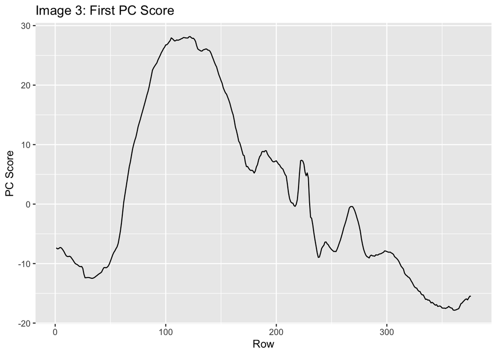

```r
ggplot(PCscore_data, aes(x = index, y = value)) +
  geom_line() +
  labs(
    x = "Row",
    y = "PC Score",
    title = "Image 3: First PC Score"
  )
```

**Interpretation:** Unlike the previous images, the scores show large and smooth changes across the rows rather than remaining relatively consistent. The scores increase from negative values to a large positive peak around rows 100–140, then generally decrease and become negative again toward the lower rows. This shows that the strength of the pattern captured by the first eigenvector changes substantially from the top to the bottom of the image. For example, in the k = 1 compression, a major part of the pattern is the dark area in the upper half of the image where the dog is located, which corresponds to the large change in PC scores around those rows.

**Sufficient k:** The image is sufficiently good at around k = 20 because the approximation error decreases rapidly over the first several principal components and begins to decrease more gradually around this point. Since Image 3 is a more complex photograph, more principal components are needed to preserve recognizable features of the dog compared to the simpler first two images. At k = 20, the major visual structure is preserved and we can begin to recognize what original image is, a dog. Increasing k further mainly adds finer details and produces progressively smaller improvements, as shown by the exponential-like decrease in approximation error.

## Image 4

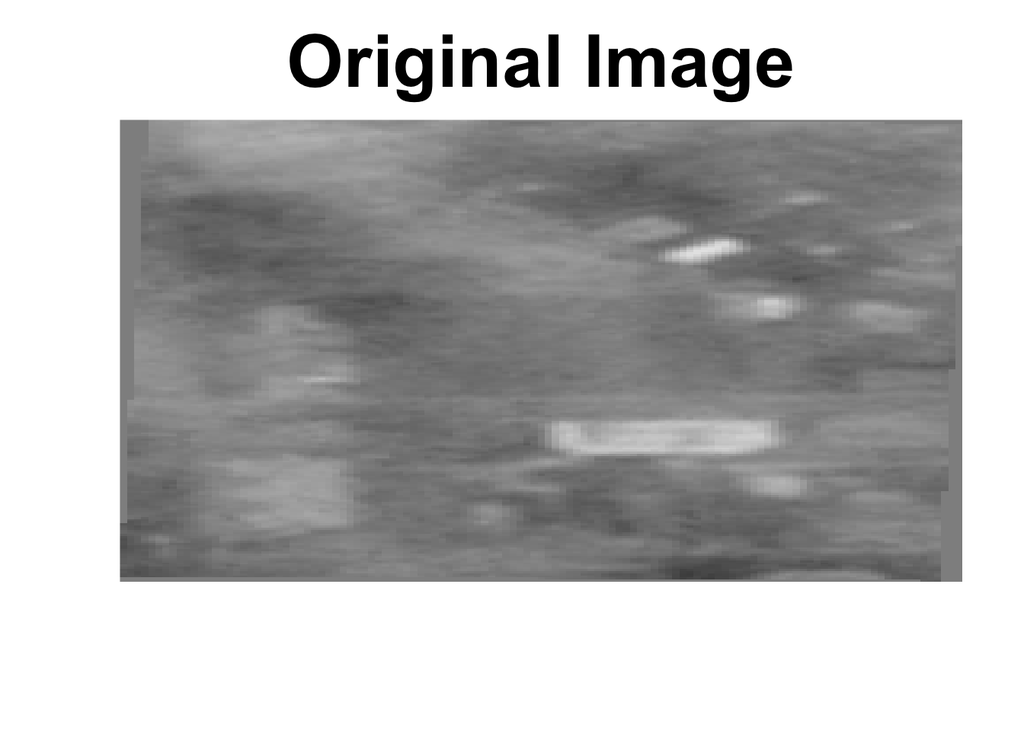

```r
# make 1x1 frame and plot og image
par(mfrow = c(1, 1))
plot_image(x4, "Original Image")
```

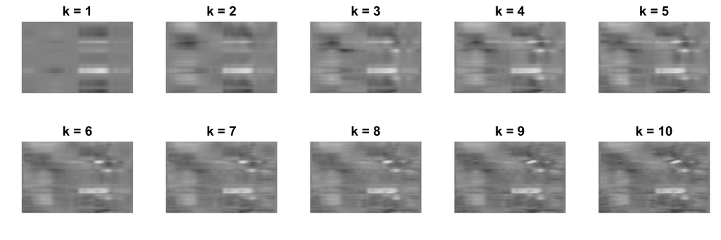

```r
# make 2x5 frame and plot compressed images k = 1-10
par(mfrow = c(2, 5))
for (k in 1:10) {
  result <- compress_image(x4, k)

  plot_image(
    result$k_approx,
    paste("k =", k)
  )
}
```

### Approximation Error vs. k

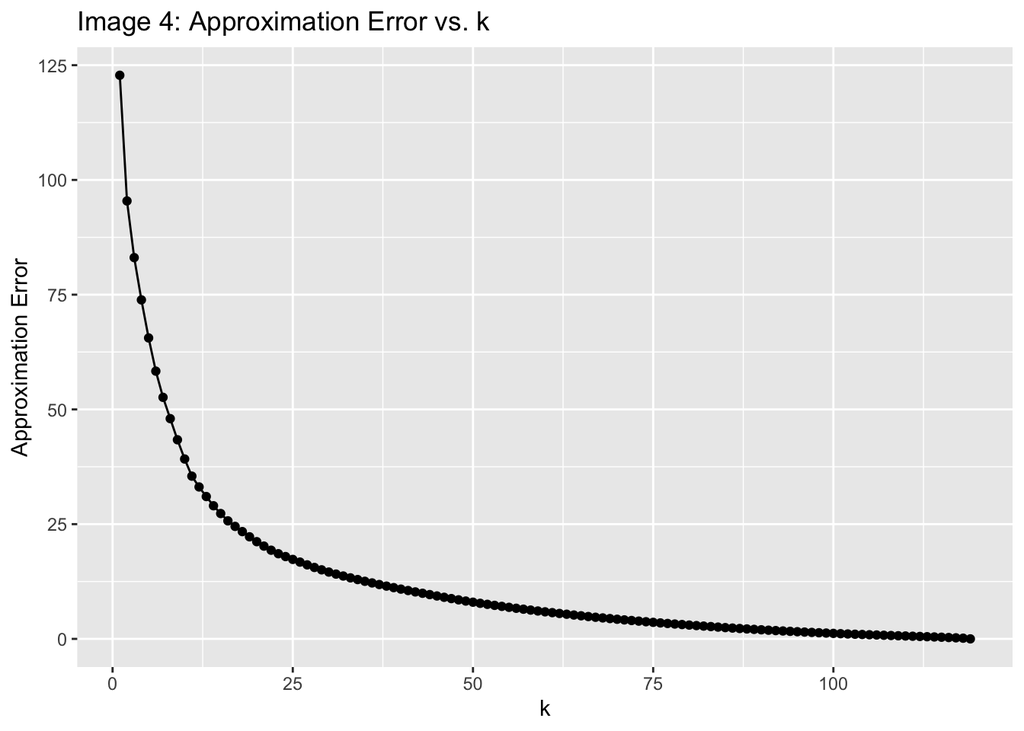

```r
k_values <- 1:ncol(x4)
error_vector <- numeric(length(k_values))

for (k in k_values) {
  result <- compress_image(x4, k)
  error_vector[k] <- result$F_error
}

error_data <- data.frame(
  k = k_values,
  error = error_vector)

ggplot(error_data, aes(x = k, y = error)) + geom_line() + geom_point() +
  labs(x = "k", y = "Approximation Error", title = "Image 4: Approximation Error vs. k")
```

### First Eigenvector and First Principal Component

```r
V <- t(x4) %*% x4
  eigen <- eigen(V)
U <- eigen$vectors
Z <- x4 %*% U
first_eigenvector <- U[, 1]
first_PCscore <- Z[, 1]

eigenvector_data <- data.frame(
  index = 1:length(first_eigenvector),
  value = first_eigenvector
)

PCscore_data <- data.frame(
  index = 1:length(first_PCscore),
  value = first_PCscore
)
```

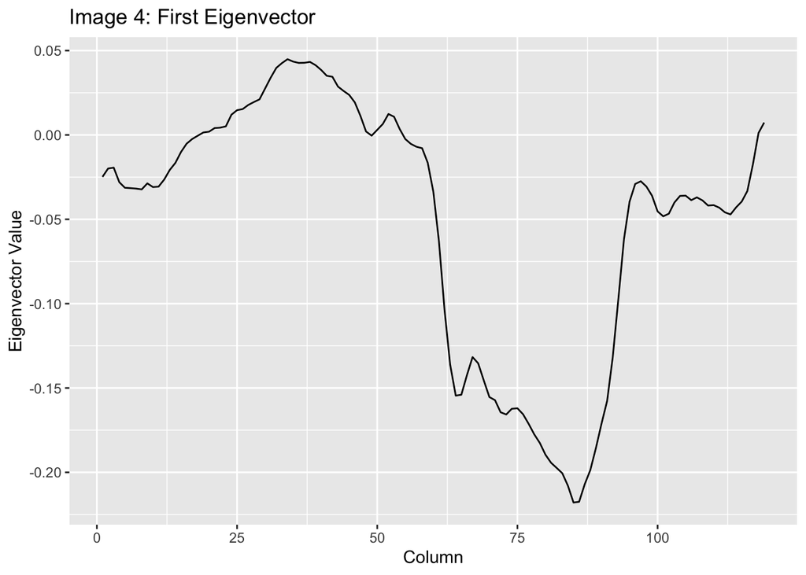

```r
ggplot(eigenvector_data, aes(x = index, y = value)) +
  geom_line() +
  labs(
    x = "Column",
    y = "Eigenvector Value",
    title = "Image 4: First Eigenvector"
  )
```

**Interpretation:** The first eigenvector varies considerably across the columns, indicating that the dominant pattern depends on multiple regions of the image rather than one specific column. The largest weights in magnitude occur approximately between columns 60 and 95, with the strongest magnitude around columns 80–90. The changing weights across the remaining columns reflect the different light and dark regions visible across the original image. For example, the large change in the eigenvector corresponds to an area with distinct light and dark patterns in the image, which can be seen most clearly in the rank-1 compression.

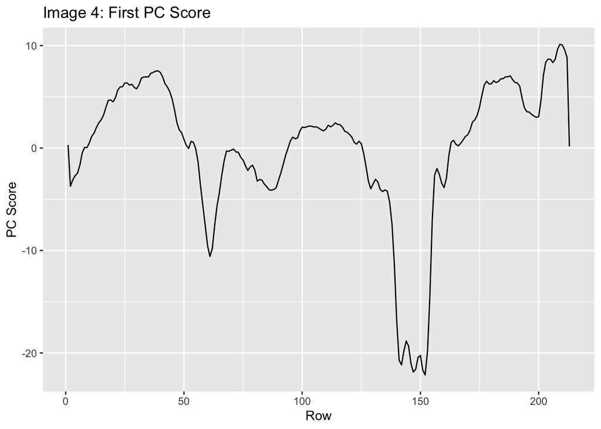

```r
ggplot(PCscore_data, aes(x = index, y = value)) +
  geom_line() +
  labs(
    x = "Row",
    y = "PC Score",
    title = "Image 4: First PC Score"
  )
```

**Interpretation:** The first PC scores show how strongly this pattern appears in each row of the image. The scores change substantially across the rows, with several peaks and dips and a particularly large change around rows 140–155. This indicates that the pattern captured by the first eigenvector is not equally present throughout the height of the image. Instead, its strength varies as the rows pass through different light and dark structures in the original image. The larger changes in the PC scores correspond to regions where the visual structure of the image changes more noticeably.

**Sufficient k:** The image is sufficiently good at k = 15 because the main visual features of the original image are already captured and recognizable. Although the approximation error continues to decrease as k increases, the curve begins to level off around this region, meaning additional principal components provide smaller improvements. Therefore, k = 15 provides a good balance between maintaining the important visual information and compressing the image.